# Credit Card Data Analysis Using Clustering & PCA

**Prasanna Prakash** in collab with **Snehal Sugandh Kamble & Piyush Anil Patil**

[figure not shown]

# **1. Objective of the Proposed Research:**

The primary objective of this project is to analyze credit card data & provide valuable insights into customer behavior, needs, and preferences. Our primary stakeholder for this project will be credit card issuing company. By examining the data, we can assist the credit card company in making data-driven decisions to improve customer satisfaction, reduce customer attrition, and enhance the overall credit card experience.

This project will thus help credit card issuer to better understand its customer base and identify specific segments with distinct characteristics. By doing so, the issuer can tailor its strategies to meet the unique needs of different customer groups. Furthermore, the analysis will uncover factors contributing to customer attrition, allowing the issuer to implement measures to retain more customers. In essence, the project is aimed at providing actionable insights that will enable the credit card issuer to optimize its operations and offer improved services.

Our project can help the company to achieve higher customer satisfaction, reduced attrition, and more effective customer engagement. With the insights generated it can guide strategic decisions, marketing teams, and customer support services resulting in business growth.

# **2. Data Exploration:**

We will explore the data below using various functions and methods to understand various dimensions of it. This will help us to decide which aspects of the data to target for further exploration

```python
#Importing necessary libraries for data manipulation, numerical operations and plotting

import pandas as pd
import numpy as np
import matplotlib.pyplot as plt
import seaborn as sns
```

```python
#reading dataset and naming it as creditdata

creditdata = pd.read_csv("/Users/prasanna/Downloads/creditcard (1).csv")

#Displaying the first 5 rows of the dataset

creditdata.head(5)
```

|  | CLIENTNUM | Attrition_Flag | Customer_Age | Gender | Dependent_count | Education_Level | Marital_Status | Income_Category | Card_Category | Months_on_book | ... | Credit_Limit | Total_Revolving_Balance | Avg_Open_To_Buy | Total_Amt_Chng_Q4_Q1 | Total_Trans_Amount | Total_Trans_Count | Total_Ct_Chng_Q4_Q1 | Avg_Utilization_Ratio | Naive_Bayes_Classifier_Attrition_Flag_Card_Category_Contacts_Count_12_mon_Dependent_count_Education_Level_Months_Inactive_12_mon_1 | Naive_Bayes_Classifier_Attrition_Flag_Card_Category_Contacts_Count_12_mon_Dependent_count_Education_Level_Months_Inactive_12_mon_2 |
| --- | --- | --- | --- | --- | --- | --- | --- | --- | --- | --- | --- | --- | --- | --- | --- | --- | --- | --- | --- | --- | --- |
| 0 | 768805383 | Existing Customer | 45 | M | 3 | High School | Married | $60K - $80K | Blue | 39 | ... | 12691.0 | 777 | 11914.0 | 1.335 | 1144 | 42 | 1.625 | 0.061 | 0.000093 | 0.99991 |
| 1 | 818770008 | Existing Customer | 49 | F | 5 | Graduate | Single | Less than $40K | Blue | 44 | ... | 8256.0 | 864 | 7392.0 | 1.541 | 1291 | 33 | 3.714 | 0.105 | 0.000057 | 0.99994 |
| 2 | 713982108 | Existing Customer | 51 | M | 3 | Graduate | Married | $80K - $120K | Blue | 36 | ... | 3418.0 | 0 | 3418.0 | 2.594 | 1887 | 20 | 2.333 | 0.000 | 0.000021 | 0.99998 |
| 3 | 769911858 | Existing Customer | 40 | F | 4 | High School | Unknown | Less than $40K | Blue | 34 | ... | 3313.0 | 2517 | 796.0 | 1.405 | 1171 | 20 | 2.333 | 0.760 | 0.000134 | 0.99987 |
| 4 | 709106358 | Existing Customer | 40 | M | 3 | Uneducated | Married | $60K - $80K | Blue | 21 | ... | 4716.0 | 0 | 4716.0 | 2.175 | 816 | 28 | 2.500 | 0.000 | 0.000022 | 0.99998 |

5 rows × 23 columns

```python
#displaying no of rows & columns of dataset

creditdata.shape
```

```
(10127, 23)
```

```python
#Display names of the columns of dataset

creditdata.columns
```

```
Index(['CLIENTNUM', 'Attrition_Flag', 'Customer_Age', 'Gender',
       'Dependent_count', 'Education_Level', 'Marital_Status',
       'Income_Category', 'Card_Category', 'Months_on_book',
       'Total_Relationship_Count', 'Months_Inactive_12_month',
       'Contacts_Count_12_month', 'Credit_Limit', 'Total_Revolving_Balance',
       'Avg_Open_To_Buy', 'Total_Amt_Chng_Q4_Q1', 'Total_Trans_Amount',
       'Total_Trans_Count', 'Total_Ct_Chng_Q4_Q1', 'Avg_Utilization_Ratio',
       'Naive_Bayes_Classifier_Attrition_Flag_Card_Category_Contacts_Count_12_mon_Dependent_count_Education_Level_Months_Inactive_12_mon_1',
       'Naive_Bayes_Classifier_Attrition_Flag_Card_Category_Contacts_Count_12_mon_Dependent_count_Education_Level_Months_Inactive_12_mon_2'],
      dtype='object')
```

```python
#Display the datatypes of each column. This will help us in further opertions

creditdata.dtypes
```

```
CLIENTNUM                                                                                                                               int64
Attrition_Flag                                                                                                                         object
Customer_Age                                                                                                                            int64
Gender                                                                                                                                 object
Dependent_count                                                                                                                         int64
Education_Level                                                                                                                        object
Marital_Status                                                                                                                         object
Income_Category                                                                                                                        object
Card_Category                                                                                                                          object
Months_on_book                                                                                                                          int64
Total_Relationship_Count                                                                                                                int64
Months_Inactive_12_month                                                                                                                int64
Contacts_Count_12_month                                                                                                                 int64
Credit_Limit                                                                                                                          float64
Total_Revolving_Balance                                                                                                                 int64
Avg_Open_To_Buy                                                                                                                       float64
Total_Amt_Chng_Q4_Q1                                                                                                                  float64
Total_Trans_Amount                                                                                                                      int64
Total_Trans_Count                                                                                                                       int64
Total_Ct_Chng_Q4_Q1                                                                                                                   float64
Avg_Utilization_Ratio                                                                                                                 float64
Naive_Bayes_Classifier_Attrition_Flag_Card_Category_Contacts_Count_12_mon_Dependent_count_Education_Level_Months_Inactive_12_mon_1    float64
Naive_Bayes_Classifier_Attrition_Flag_Card_Category_Contacts_Count_12_mon_Dependent_count_Education_Level_Months_Inactive_12_mon_2    float64
dtype: object
```

```python
#calculate the count of unique values in each column of dataset

creditdata.nunique()
```

```
CLIENTNUM                                                                                                                             10127
Attrition_Flag                                                                                                                            2
Customer_Age                                                                                                                             45
Gender                                                                                                                                    2
Dependent_count                                                                                                                           6
Education_Level                                                                                                                           7
Marital_Status                                                                                                                            4
Income_Category                                                                                                                           6
Card_Category                                                                                                                             4
Months_on_book                                                                                                                           44
Total_Relationship_Count                                                                                                                  6
Months_Inactive_12_month                                                                                                                  7
Contacts_Count_12_month                                                                                                                   7
Credit_Limit                                                                                                                           6205
Total_Revolving_Balance                                                                                                                1974
Avg_Open_To_Buy                                                                                                                        6813
Total_Amt_Chng_Q4_Q1                                                                                                                   1158
Total_Trans_Amount                                                                                                                     5033
Total_Trans_Count                                                                                                                       126
Total_Ct_Chng_Q4_Q1                                                                                                                     830
Avg_Utilization_Ratio                                                                                                                   964
Naive_Bayes_Classifier_Attrition_Flag_Card_Category_Contacts_Count_12_mon_Dependent_count_Education_Level_Months_Inactive_12_mon_1     1591
Naive_Bayes_Classifier_Attrition_Flag_Card_Category_Contacts_Count_12_mon_Dependent_count_Education_Level_Months_Inactive_12_mon_2      640
dtype: int64
```

```python
#Calculating missing values and count of missing values in each column

creditdata.isna().sum()
```

```
CLIENTNUM                                                                                                                             0
Attrition_Flag                                                                                                                        0
Customer_Age                                                                                                                          0
Gender                                                                                                                                0
Dependent_count                                                                                                                       0
Education_Level                                                                                                                       0
Marital_Status                                                                                                                        0
Income_Category                                                                                                                       0
Card_Category                                                                                                                         0
Months_on_book                                                                                                                        0
Total_Relationship_Count                                                                                                              0
Months_Inactive_12_month                                                                                                              0
Contacts_Count_12_month                                                                                                               0
Credit_Limit                                                                                                                          0
Total_Revolving_Balance                                                                                                               0
Avg_Open_To_Buy                                                                                                                       0
Total_Amt_Chng_Q4_Q1                                                                                                                  0
Total_Trans_Amount                                                                                                                    0
Total_Trans_Count                                                                                                                     0
Total_Ct_Chng_Q4_Q1                                                                                                                   0
Avg_Utilization_Ratio                                                                                                                 0
Naive_Bayes_Classifier_Attrition_Flag_Card_Category_Contacts_Count_12_mon_Dependent_count_Education_Level_Months_Inactive_12_mon_1    0
Naive_Bayes_Classifier_Attrition_Flag_Card_Category_Contacts_Count_12_mon_Dependent_count_Education_Level_Months_Inactive_12_mon_2    0
dtype: int64
```

# **3. Data Cleaning:**

In our analysis, we deleted 2 columns which were not useful for us.

```python
# Specify the columns we want to delete

delete_columns = ['Naive_Bayes_Classifier_Attrition_Flag_Card_Category_Contacts_Count_12_mon_Dependent_count_Education_Level_Months_Inactive_12_mon_1','Naive_Bayes_Classifier_Attrition_Flag_Card_Category_Contacts_Count_12_mon_Dependent_count_Education_Level_Months_Inactive_12_mon_2']

#Delete the selected columns

creditdata.drop(columns=delete_columns, inplace=True)
creditdata.head()
```

|  | CLIENTNUM | Attrition_Flag | Customer_Age | Gender | Dependent_count | Education_Level | Marital_Status | Income_Category | Card_Category | Months_on_book | ... | Months_Inactive_12_month | Contacts_Count_12_month | Credit_Limit | Total_Revolving_Balance | Avg_Open_To_Buy | Total_Amt_Chng_Q4_Q1 | Total_Trans_Amount | Total_Trans_Count | Total_Ct_Chng_Q4_Q1 | Avg_Utilization_Ratio |
| --- | --- | --- | --- | --- | --- | --- | --- | --- | --- | --- | --- | --- | --- | --- | --- | --- | --- | --- | --- | --- | --- |
| 0 | 768805383 | Existing Customer | 45 | M | 3 | High School | Married | $60K - $80K | Blue | 39 | ... | 1 | 3 | 12691.0 | 777 | 11914.0 | 1.335 | 1144 | 42 | 1.625 | 0.061 |
| 1 | 818770008 | Existing Customer | 49 | F | 5 | Graduate | Single | Less than $40K | Blue | 44 | ... | 1 | 2 | 8256.0 | 864 | 7392.0 | 1.541 | 1291 | 33 | 3.714 | 0.105 |
| 2 | 713982108 | Existing Customer | 51 | M | 3 | Graduate | Married | $80K - $120K | Blue | 36 | ... | 1 | 0 | 3418.0 | 0 | 3418.0 | 2.594 | 1887 | 20 | 2.333 | 0.000 |
| 3 | 769911858 | Existing Customer | 40 | F | 4 | High School | Unknown | Less than $40K | Blue | 34 | ... | 4 | 1 | 3313.0 | 2517 | 796.0 | 1.405 | 1171 | 20 | 2.333 | 0.760 |
| 4 | 709106358 | Existing Customer | 40 | M | 3 | Uneducated | Married | $60K - $80K | Blue | 21 | ... | 1 | 0 | 4716.0 | 0 | 4716.0 | 2.175 | 816 | 28 | 2.500 | 0.000 |

5 rows × 21 columns

```python
#Cross checking data dimensions. column numbers should from 23 to 21

creditdata.shape
```

```
(10127, 21)
```

```python
# Find unique values in Income_Category column

uniquevalues = creditdata['Income_Category'].unique()

uniquevalues
```

```
array(['$60K - $80K', 'Less than $40K', '$80K - $120K', '$40K - $60K',
       '$120K +', 'Unknown'], dtype=object)
```

# **4. Adaptation:**

We created a new column to group values from Customer_Age column. This catagorisation of customer age into age groups will be useful in further analsis and clustering

```python
#creating age bins of 5 year each from age 26
age_bins = [26, 30, 35, 40, 45, 50, 55, 60, 65, 70, 75, 80]

#Let's  define labels for age groups
bin_label = ['26-30', '31-35', '36-40', '41-45', '46-50', '51-55', '56-60', '61-65', '66-70', '71-75', '76-80']

#Let's use pd.cut() to categorize ages into age groups
creditdata['Age_Group'] = pd.cut(creditdata['Customer_Age'], bins=age_bins, labels=bin_label)

#display data with the new "Age_Group" column
creditdata.head()
```

|  | CLIENTNUM | Attrition_Flag | Customer_Age | Gender | Dependent_count | Education_Level | Marital_Status | Income_Category | Card_Category | Months_on_book | ... | Contacts_Count_12_month | Credit_Limit | Total_Revolving_Balance | Avg_Open_To_Buy | Total_Amt_Chng_Q4_Q1 | Total_Trans_Amount | Total_Trans_Count | Total_Ct_Chng_Q4_Q1 | Avg_Utilization_Ratio | Age_Group |
| --- | --- | --- | --- | --- | --- | --- | --- | --- | --- | --- | --- | --- | --- | --- | --- | --- | --- | --- | --- | --- | --- |
| 0 | 768805383 | Existing Customer | 45 | M | 3 | High School | Married | $60K - $80K | Blue | 39 | ... | 3 | 12691.0 | 777 | 11914.0 | 1.335 | 1144 | 42 | 1.625 | 0.061 | 41-45 |
| 1 | 818770008 | Existing Customer | 49 | F | 5 | Graduate | Single | Less than $40K | Blue | 44 | ... | 2 | 8256.0 | 864 | 7392.0 | 1.541 | 1291 | 33 | 3.714 | 0.105 | 46-50 |
| 2 | 713982108 | Existing Customer | 51 | M | 3 | Graduate | Married | $80K - $120K | Blue | 36 | ... | 0 | 3418.0 | 0 | 3418.0 | 2.594 | 1887 | 20 | 2.333 | 0.000 | 51-55 |
| 3 | 769911858 | Existing Customer | 40 | F | 4 | High School | Unknown | Less than $40K | Blue | 34 | ... | 1 | 3313.0 | 2517 | 796.0 | 1.405 | 1171 | 20 | 2.333 | 0.760 | 36-40 |
| 4 | 709106358 | Existing Customer | 40 | M | 3 | Uneducated | Married | $60K - $80K | Blue | 21 | ... | 0 | 4716.0 | 0 | 4716.0 | 2.175 | 816 | 28 | 2.500 | 0.000 | 36-40 |

5 rows × 22 columns

Let's create 2 more columns Credit_Balance, Years_on_Book which will be useful in further analysis using following formulae :

Credit_Balance (credit balance = credit limit - total transaction amount )

Years_on_Book (year = months/12)

```python
# Create 2 new columns Credit_Limit, Years_on_Book and Age_Group

creditdata['Credit_Balance'] = creditdata['Credit_Limit'] - creditdata['Total_Trans_Amount']
creditdata['Years_on_Book'] = creditdata['Months_on_book'] / 12
creditdata['Years_on_Book'] = creditdata['Years_on_Book'].round(2)
```

```python
creditdata.head()
```

|  | CLIENTNUM | Attrition_Flag | Customer_Age | Gender | Dependent_count | Education_Level | Marital_Status | Income_Category | Card_Category | Months_on_book | ... | Total_Revolving_Balance | Avg_Open_To_Buy | Total_Amt_Chng_Q4_Q1 | Total_Trans_Amount | Total_Trans_Count | Total_Ct_Chng_Q4_Q1 | Avg_Utilization_Ratio | Age_Group | Credit_Balance | Years_on_Book |
| --- | --- | --- | --- | --- | --- | --- | --- | --- | --- | --- | --- | --- | --- | --- | --- | --- | --- | --- | --- | --- | --- |
| 0 | 768805383 | Existing Customer | 45 | M | 3 | High School | Married | $60K - $80K | Blue | 39 | ... | 777 | 11914.0 | 1.335 | 1144 | 42 | 1.625 | 0.061 | 41-45 | 11547.0 | 3.25 |
| 1 | 818770008 | Existing Customer | 49 | F | 5 | Graduate | Single | Less than $40K | Blue | 44 | ... | 864 | 7392.0 | 1.541 | 1291 | 33 | 3.714 | 0.105 | 46-50 | 6965.0 | 3.67 |
| 2 | 713982108 | Existing Customer | 51 | M | 3 | Graduate | Married | $80K - $120K | Blue | 36 | ... | 0 | 3418.0 | 2.594 | 1887 | 20 | 2.333 | 0.000 | 51-55 | 1531.0 | 3.00 |
| 3 | 769911858 | Existing Customer | 40 | F | 4 | High School | Unknown | Less than $40K | Blue | 34 | ... | 2517 | 796.0 | 1.405 | 1171 | 20 | 2.333 | 0.760 | 36-40 | 2142.0 | 2.83 |
| 4 | 709106358 | Existing Customer | 40 | M | 3 | Uneducated | Married | $60K - $80K | Blue | 21 | ... | 0 | 4716.0 | 2.175 | 816 | 28 | 2.500 | 0.000 | 36-40 | 3900.0 | 1.75 |

5 rows × 24 columns

# **5. Descriptive Static Visualization:**

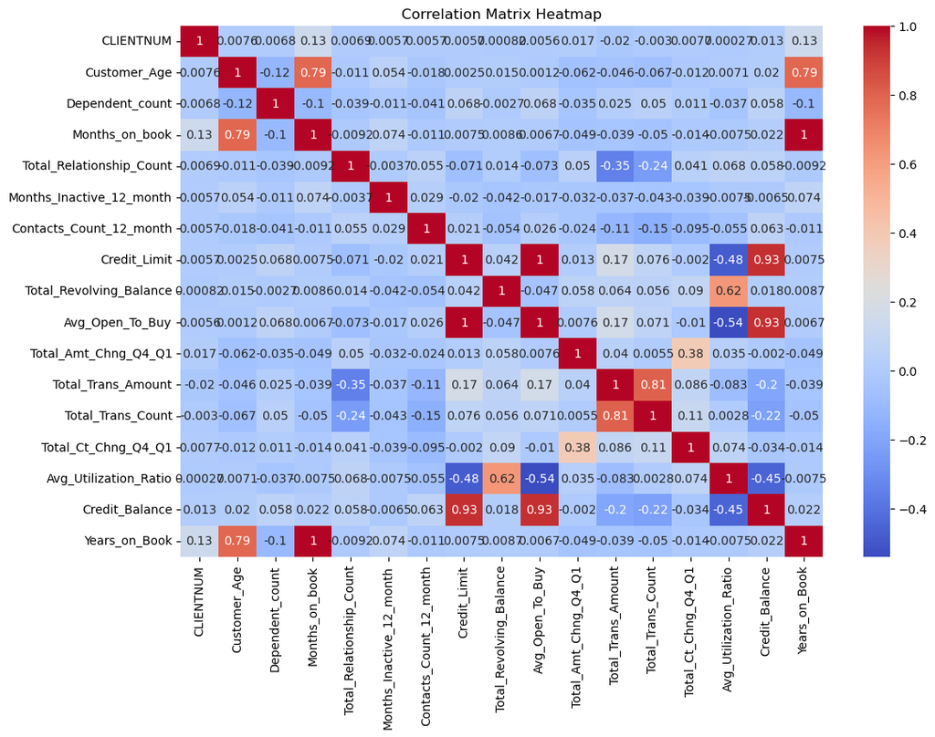

```python
#correlation matrix
correlation_matrix = creditdata.corr()

#heatmap creation
plt.figure(figsize=(12, 8))
sns.heatmap(correlation_matrix, annot=True, cmap='coolwarm')
plt.title('Correlation Matrix Heatmap')
plt.show()
```

This correlation matrix plot displays the relationships between multiple numerical variables. It uses color coding to show the strength and direction of correlations. red colours shows highest positive correlation. Apart from obvious correlations, following are of of some interest.

1. Years on book - Customer Age (positive correlation)
2. Total Transaction amount- Total relationship count (negative correlation)

We would like to dveleve more into these correlations in our further analysis.

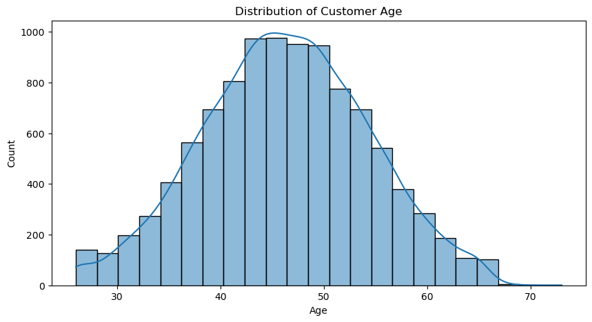

```python
# Visualizing the distribution of Customer_Age
plt.figure(figsize=(10, 5))
sns.histplot(creditdata['Customer_Age'], bins=23, kde=True)
plt.title('Distribution of Customer Age')
plt.xlabel('Age')
plt.ylabel('Count')
plt.show()
```

The above histogram shows the distribution of customer ages in the dataset, displaying the count of customers in each age bin. We have created such 23 bins to helps in understanding the distribution and central tendency of customer ages in the dataset.

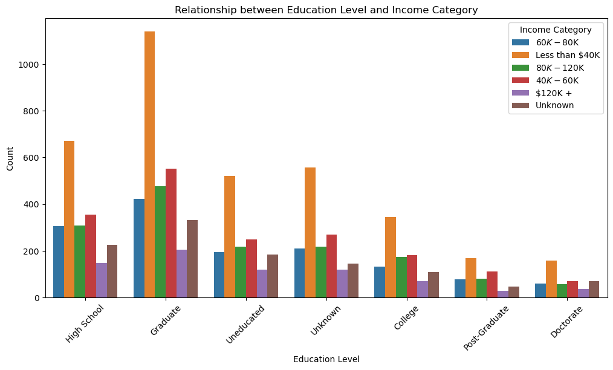

```python
#plotting countplot to show relationship between Education_Level and Income_Category
plt.figure(figsize=(12, 6))
sns.countplot(x='Education_Level', hue='Income_Category', data=creditdata)
plt.title('Relationship between Education Level and Income Category')
plt.xlabel('Education Level')
plt.ylabel('Count')
plt.xticks(rotation=45)
plt.legend(title='Income Category')
plt.show()
```

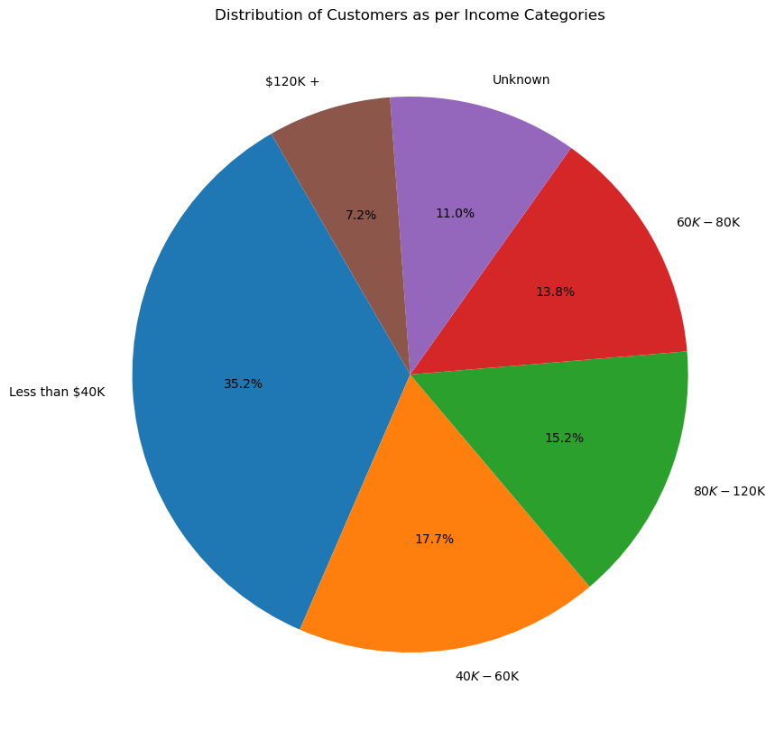

```python
#counting no of customers for each income category before creating pie chart
card_category_counts = creditdata['Income_Category'].value_counts()

#creating a pie chart
plt.figure(figsize=(10,10))
plt.pie(card_category_counts, labels=card_category_counts.index, autopct='%1.1f%%', startangle=120)
plt.title('Distribution of Customers as per Income Categories')
plt.show()
```

Above pie chart visualizes distribution of income catagory of customers using a pie chart to understand the relative proportions of customers in each income category. It can be seen that 'less than 40k' income group constitues largest chunk with around 35% while the highest income group (120k+) has around 7% share.

**Label Encoding :**

For Attrition_Flag, Gender, and Income_Category, we used label encoding. For Education_Level, Marital_Status, and Card_Category, we used one-hot encoding.

```python
from sklearn.preprocessing import LabelEncoder

#initialising LabelEncoder
label_encoder = LabelEncoder()

# let's select columns to label encode
label_cols = ['Attrition_Flag', 'Gender', 'Income_Category']
for col in label_cols:
    creditdata[col] = label_encoder.fit_transform(creditdata[col])

# let's select columns to hot encode
onehot_cols = ['Education_Level', 'Marital_Status', 'Card_Category', 'Age_Group']
creditdata_encoded = pd.get_dummies(creditdata, columns=onehot_cols)
creditdata_encoded.head()
```

|  | CLIENTNUM | Attrition_Flag | Customer_Age | Gender | Dependent_count | Income_Category | Months_on_book | Total_Relationship_Count | Months_Inactive_12_month | Contacts_Count_12_month | ... | Age_Group_31-35 | Age_Group_36-40 | Age_Group_41-45 | Age_Group_46-50 | Age_Group_51-55 | Age_Group_56-60 | Age_Group_61-65 | Age_Group_66-70 | Age_Group_71-75 | Age_Group_76-80 |
| --- | --- | --- | --- | --- | --- | --- | --- | --- | --- | --- | --- | --- | --- | --- | --- | --- | --- | --- | --- | --- | --- |
| 0 | 768805383 | 1 | 45 | 1 | 3 | 2 | 39 | 5 | 1 | 3 | ... | 0 | 0 | 1 | 0 | 0 | 0 | 0 | 0 | 0 | 0 |
| 1 | 818770008 | 1 | 49 | 0 | 5 | 4 | 44 | 6 | 1 | 2 | ... | 0 | 0 | 0 | 1 | 0 | 0 | 0 | 0 | 0 | 0 |
| 2 | 713982108 | 1 | 51 | 1 | 3 | 3 | 36 | 4 | 1 | 0 | ... | 0 | 0 | 0 | 0 | 1 | 0 | 0 | 0 | 0 | 0 |
| 3 | 769911858 | 1 | 40 | 0 | 4 | 4 | 34 | 3 | 4 | 1 | ... | 0 | 1 | 0 | 0 | 0 | 0 | 0 | 0 | 0 | 0 |
| 4 | 709106358 | 1 | 40 | 1 | 3 | 2 | 21 | 5 | 1 | 0 | ... | 0 | 1 | 0 | 0 | 0 | 0 | 0 | 0 | 0 | 0 |

5 rows × 46 columns

# Cluster Analysis :

## **Feature Selection for clustering**

**Customer_Age:** Age could be a significant factor in determining customer behavior and preferences.

**Income_Category:** Income level can heavily influence spending patterns and credit usage.

**Total_Relationship_Count:** It gives an idea about the customer's engagement with the bank.

**Months_Inactive_12_month:** It can be a precursor to attrition.

**Contacts_Count_12_month:** The number of contacts can indicate customer engagement or issues.

**Credit_Limit:** Indicates the trust level and spending capacity of a customer.

**Total_Revolving_Balance:** Can indicate how much credit the customer typically uses.

**Total_Trans_Amount:** Total amount spent can indicate customer engagement and spending patterns.

**Total_Trans_Count:** The frequency of transactions can also indicate engagement.

**Total_Ct_Chng_Q4_Q1:** Change in transaction count can indicate a change in customer behavior.

**Avg_Utilization_Ratio:** Indicates how much of the credit limit is being utilized.

## **7. Dendrogram:**

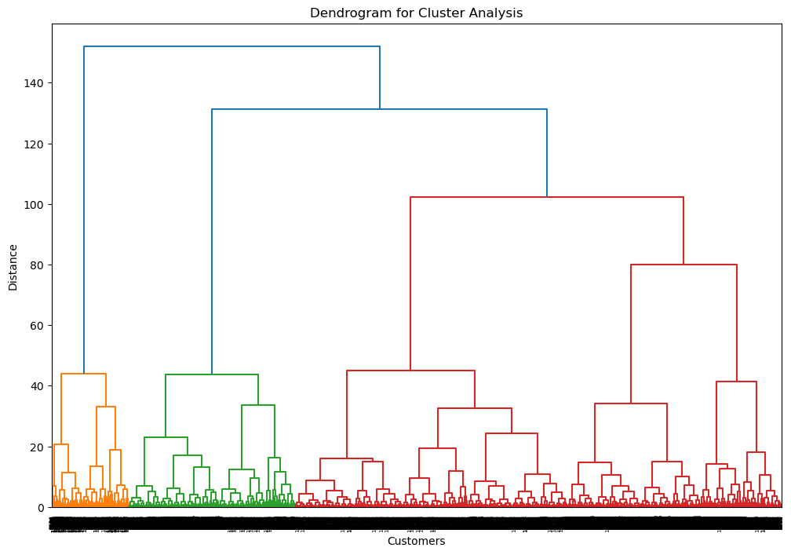

```python
import pandas as pd
import matplotlib.pyplot as plt
import scipy.cluster.hierarchy as shc
from sklearn.preprocessing import StandardScaler
from sklearn.decomposition import PCA

#selecting important features for clustering
important_features = ['Customer_Age',
    'Attrition_Flag',
    'Income_Category',
    'Months_on_book',
    'Total_Relationship_Count',
    'Total_Trans_Count',
    'Total_Trans_Amount',
    'Months_Inactive_12_month'
]

#subseting the data
subset_data_important = creditdata_encoded[important_features]

#standardizing the data
scaler = StandardScaler()
scaled_subset_data = scaler.fit_transform(subset_data_important)

#we had to use PCA to reduce dimensionality and better computation
pca = PCA(n_components=2)
reduced_data = pca.fit_transform(scaled_subset_data)

#create dendrogram
plt.figure(figsize=(12, 8))
dendrogram = shc.dendrogram(shc.linkage(reduced_data, method='ward'))
plt.title('Dendrogram for Cluster Analysis')
plt.xlabel('Customers')
plt.ylabel('Distance')
plt.show()
```

**Insights:**

The y-axis represents the Euclidean distance between points. Larger distances suggest that points are less similar to each other.

**Cluster Proximity**: The height of the branches in the dendrogram is moderate which means clusters are not similar to each other.

**Customer Segments:** Different heights at which branches merge indicate the diversity in customer behavior. mergers at low height means groups are closely related.

**Inactivity & Relationships:** Customers who are inactive and have fewer products with the bank could potentially fall into similar clusters, indicating they might be 'bad' or 'unhappy' customers.

**Attrition:** The presence of the Attrition_Flag in the data may lead to clusters that could directly indicate customer attrition or the lack thereof, which is highly valuable for the bank.

# 8. Hierarchical clustering

We will use AgglomerativeClustering here.It's a bottom-up approach where each data point starts as its own cluster and then iteratively merges the closest clusters until a stopping criterion is met. The feature selection remains the same as previous.

```
                Customer_Age  Attrition_Flag  Income_Category  Months_on_book  \
Cluster_Labels
0                  46.373743             1.0         2.871421       35.963890
1                  46.659496             0.0         2.924401       36.178242
2                  45.101877             1.0         2.654155       35.014745

                Total_Relationship_Count  Total_Trans_Count  \
Cluster_Labels
0                               4.064225          64.662368
1                               3.279656          44.933620
2                               2.359249         110.355228

                Total_Trans_Amount  Months_Inactive_12_month
Cluster_Labels
0                      3688.243487                  2.279727
1                      3095.025814                  2.693301
2                     14699.644772                  2.211796
```

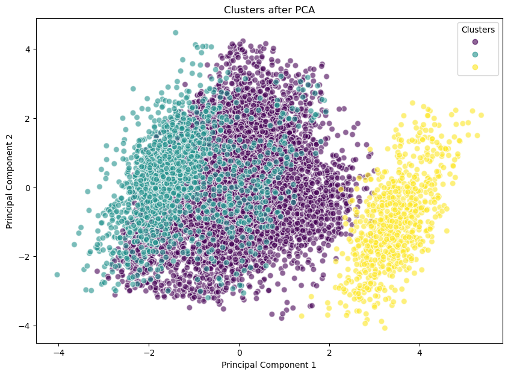

```python
from sklearn.preprocessing import StandardScaler
from sklearn.cluster import AgglomerativeClustering

#selecting important features for clustering
important_features = ['Customer_Age',
    'Attrition_Flag',
    'Income_Category',
    'Months_on_book',
    'Total_Relationship_Count',
    'Total_Trans_Count',
    'Total_Trans_Amount',
    'Months_Inactive_12_month'
]

#subsetting the data
subset_data_important = creditdata_encoded[important_features]

#standardizing the data
scaler = StandardScaler()
scaled_subset_data = scaler.fit_transform(subset_data_important)

#Let's now perform AgglomerativeClustering

#assuming 3 clusters. (in dendogram, we could see 3 clusters emerging)
n_clusters = 3
agg_clustering = AgglomerativeClustering(n_clusters=n_clusters, affinity='euclidean', linkage='ward')
cluster_labels = agg_clustering.fit_predict(scaled_subset_data)

#Let's add cluster labels to our data
creditdata_encoded['Cluster_Labels'] = cluster_labels

#examine the characteristics of each cluster
cluster_summary = creditdata_encoded.groupby('Cluster_Labels')[important_features].mean()
print(cluster_summary)

#pca and lotting

import matplotlib.pyplot as plt
from sklearn.decomposition import PCA

# Use PCA to reduce the dimensionality of the data
pca = PCA(n_components=2)
reduced_data = pca.fit_transform(scaled_subset_data)

# Scatter plot
plt.figure(figsize=(10, 7))
scatter = plt.scatter(reduced_data[:, 0], reduced_data[:, 1], c=cluster_labels, cmap='viridis', s=50, edgecolors='w', alpha=0.6)
plt.title('Clusters after PCA')
plt.xlabel('Principal Component 1')
plt.ylabel('Principal Component 2')

# Add legend
handles, _ = scatter.legend_elements(prop="colors")
plt.legend(handles=handles, title="Clusters")

plt.show()
```

# **Insights**

**Cluster 1:"Low-Engagement Customers"**

**Cluster 2: "High-Value Active Customers"**

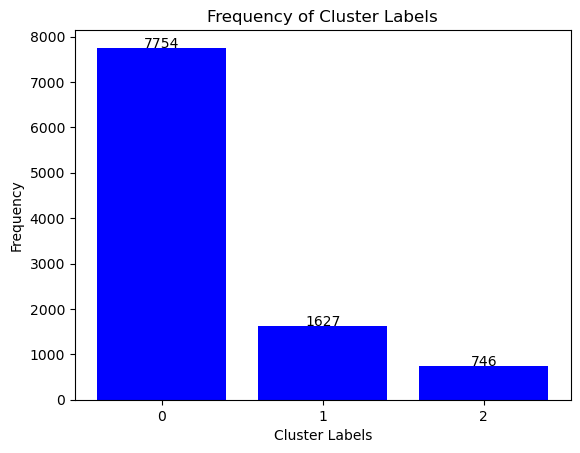

```python
# Plotting the frequency of each cluster label
unique_clusters, counts = np.unique(cluster_labels, return_counts=True)
plt.bar(unique_clusters, counts, color='blue')
plt.xlabel('Cluster Labels')
plt.ylabel('Frequency')
plt.title('Frequency of Cluster Labels')
plt.xticks(unique_clusters)

# Annotate the bar chart with the counts
for i, count in enumerate(counts):
    plt.text(i, count, str(count), ha='center')

plt.show()
```

# **9. sklearn.cluster:**

```
                       Attrition_Flag  Income_Category  Months_on_book  \
KMeans_Cluster_Labels
0                            0.000000         2.924877       36.201970
1                            0.998195         2.728039       35.675692
2                            1.000000         2.882473       35.924865

                       Total_Relationship_Count  Total_Trans_Count  \
KMeans_Cluster_Labels
0                                      3.283251          44.856527
1                                      1.950662          97.195548
2                                      4.390586          61.750914

                       Total_Trans_Amount  Months_Inactive_12_month
KMeans_Cluster_Labels
0                             3085.134236                  2.695197
1                            10147.796631                  2.198556
2                             3321.778395                  2.291770
```

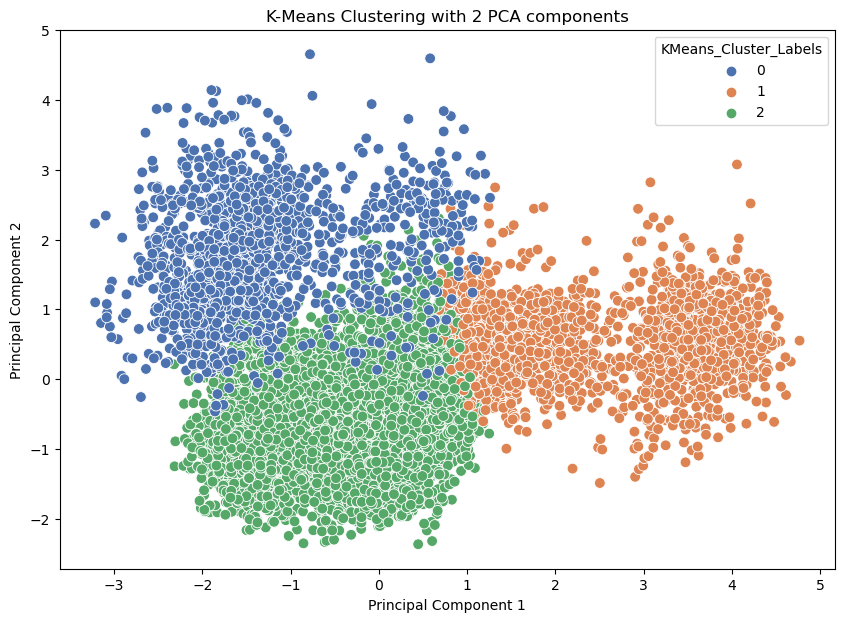

```python
from sklearn.cluster import KMeans

#Load your data
# creditdata_encoded = pd.read_csv('path_to_your_file.csv')

# select important features for clustering
important_features = [
    'Attrition_Flag',
    'Income_Category',
    'Months_on_book',
    'Total_Relationship_Count',
    'Total_Trans_Count',
    'Total_Trans_Amount',
    'Months_Inactive_12_month'
]

# Subsetting the data
subset_data_important = creditdata_encoded[important_features]

# Standardize the data
scaler = StandardScaler()
scaled_subset_data = scaler.fit_transform(subset_data_important)

# consider number of clusters
n_clusters = 3

# Perform K-Means clustering
kmeans = KMeans(n_clusters=n_clusters, random_state=42)
kmeans_labels = kmeans.fit_predict(scaled_subset_data)

# Add the K-Means cluster labels to your original data
creditdata_encoded['KMeans_Cluster_Labels'] = kmeans_labels

# Examine the characteristics of each K-Means cluster
kmeans_cluster_summary = creditdata_encoded.groupby('KMeans_Cluster_Labels')[important_features].mean()
print(kmeans_cluster_summary)


from sklearn.decomposition import PCA
import matplotlib.pyplot as plt

# Reduce dimensionality using PCA
pca = PCA(n_components=2)
principal_components = pca.fit_transform(scaled_subset_data)

# Create a df with PCA results and cluster labels
df_pca = pd.DataFrame(data=principal_components, columns=['Principal Component 1', 'Principal Component 2'])
df_pca['KMeans_Cluster_Labels'] = kmeans_labels

# Plot the data
plt.figure(figsize=(10, 7))
sns.scatterplot(x="Principal Component 1", y="Principal Component 2", hue="KMeans_Cluster_Labels", data=df_pca, palette="deep", s=60)
plt.title('K-Means Clustering with 2 PCA components')
plt.show()
```

**Summary Insights by K-Means Cluster**

## **10. kNN Function:**

```python
from scipy.spatial.distance import euclidean

#function to predict label using k-Nearest Neighbors algorithm
def predictKNN(k, data_point, data, labels):
    # Calculate distances between the data_point and all points in data
    distances = [euclidean(data_point, point) for point in data.values]
    # Get indices of k smallest distances
    k_indices = np.argsort(distances)[:k]
    # Get the labels corresponding to these k indices
    k_labels = labels.iloc[k_indices]
    # Return the most common label among the k neighbors as prediction
    return k_labels.mode()[0]

#generate some sample data for demonstration
sample_data = creditdata_encoded.sample(100)
sample_labels = np.random.choice([0, 1], size=100)

#Let's run the kNN function 6 times with different parameters
k_values = [1, 3, 5, 7, 9, 11]
data_point = sample_data.iloc[0]  # random data point

knn_results = [predictKNN(k, data_point, sample_data, pd.Series(sample_labels)) for k in k_values]

knn_results
```

```
[1, 1, 1, 1, 1, 1]
```

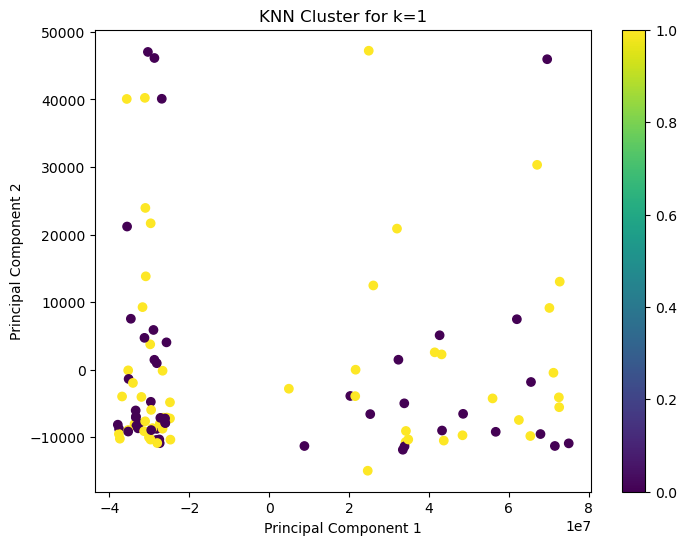

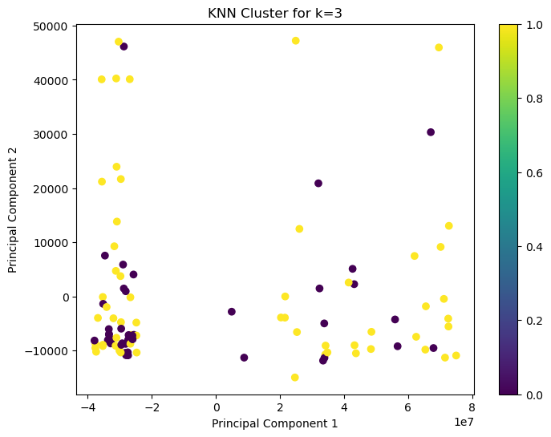

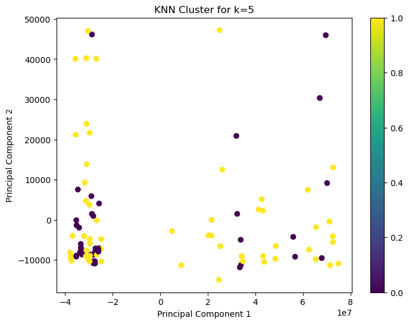

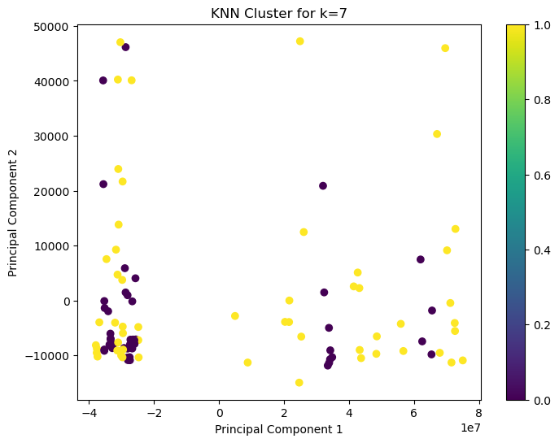

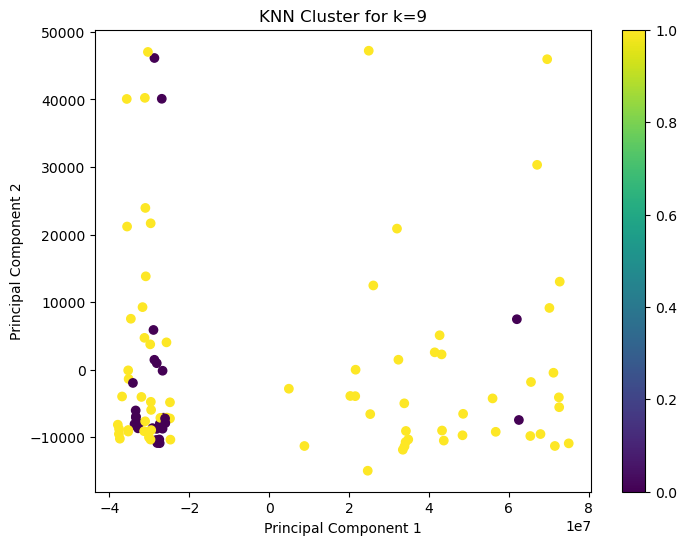

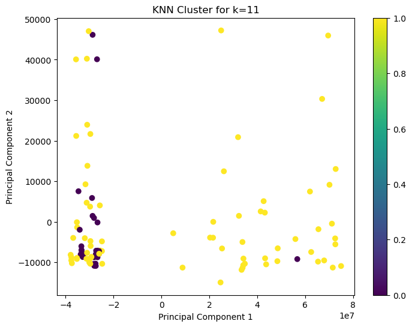

```
KNN Results:
k=1: Predicted label = 1
k=3: Predicted label = 1
k=5: Predicted label = 1
k=7: Predicted label = 1
k=9: Predicted label = 1
k=11: Predicted label = 1
```

```python
import matplotlib.pyplot as plt
from sklearn.decomposition import PCA

# Define a function to plot the KNN cluster
def plotKNNCluster(data, labels, title):
    pca = PCA(n_components=2)
    reduced_data = pca.fit_transform(data)
    plt.figure(figsize=(8, 6))
    plt.scatter(reduced_data[:, 0], reduced_data[:, 1], c=labels, cmap='viridis')
    plt.title(title)
    plt.xlabel('Principal Component 1')
    plt.ylabel('Principal Component 2')
    plt.colorbar()
    plt.show()

# Plot the KNN cluster for each k value
for i, k in enumerate(k_values):
    knn_labels = [predictKNN(k, point, sample_data, pd.Series(sample_labels)) for point in sample_data.values]
    plotKNNCluster(sample_data, knn_labels, f'KNN Cluster for k={k}')

# Display the KNN results
print("KNN Results:")
for k, result in zip(k_values, knn_results):
    print(f"k={k}: Predicted label = {result}")
```

Reasons :

Consistent Label Prediction: The predicted label for the selected data point remained the same ('1') regardless of the number of neighbors considered.

Stability in Prediction: This implies that the majority label among the nearest neighbors, based on the Euclidean distance, is consistently the same label ('1') for the given data point.

Limitation of Sample Data: The uniformity in predicted labels across 'k' values might be due to the specific nature or distribution of the sample data used, potentially limiting the understanding of the model's adaptability

## **11. Project Report:**

This project was aimed for a rigorous analysis of credit card customer data to yield actionable insights for informed decision-making. We aim to enhance customer satisfaction and minimize attrition rates. This report consolidates our findings and proposes targeted recommendations for our diverse customer segments.

We employed a variety of tools by utilizing correlation matrices, histograms, and pie charts for initial insights. Key features were selected for advanced cluster analysis to derive nuanced customer behavior metrics.

**Key Insights and Immediate Actions**

**Correlation Matrix:**

We have found the fairly good correlations between 'Years on Book' and 'Customer Age' and an inverse relation between 'Total Transaction Amount' and 'Total Relationship Count.'

**Action:** We recommend to initiate further analysis on age-related spending and relationship-spending paradox.

**Demographic Profile:** Through our analysis we have identified Predominant age groups.

**Action:** Launch age-segmented marketing campaigns for age group between 40-50

**Income and Education:** Variability in income across educational levels was found.

**Action:** We recommend to implement financial literacy programs tailored to educational tiers.

**Income Distribution:** Large segment earns below $40,000 annually.

**Recommendation:**

Introduce low-interest credit offerings for this demographic.

# **Cluster-Specific Recommendations**

We advise to initiate personalized surveys and direct communications; offer customized incentives and flexible repayment plans to prevent attrition of this segment of customer

**Low-Engagement Customers (Cluster 1):**

We recommend to undertake Commence re-engagement campaigns and introduce cash-back and loyalty rewards to increase engagement of this segment of customer.

**Overall Strategic Recommendations**

**Future Outlook**

Action Point: Strategic investments in machine learning capabilities are strongly advised.

**Conclusion**

This streamlined report provides data-backed recommendations for data-driven, customer-centric strategies. We believe that by delivering on our actionable it is possible to significantly elevate customer satisfaction and reduce attrition rates.

# **Originality**

**No other similar published works for linear regression found with same dataset**

References:

1. Stack Overflow
2. You tube vidoes about clustering
3. Zybook